# Length-Frequency Analysis for Stock Assessment

Selected species of tuna and tuna-like fish in Somalia Water

Author

Rushingisha George, Masumbuko Semba, and Mathew Silas

Published

December 16, 2025

Modified

December 19, 2025

**What we’re doing:** Load the R packages required for length-frequency analysis and stock assessment.

```r
# Load required libraries
library(tidyverse)      # Data manipulation and visualization
library(sizeMat)        # For maturity analysis
library(gt)             # For professional tables
require(TropFishR)      # Tropical fisheries stock assessment
```

# Introduction

This document provides a step-by-step guide to analyzing length-frequency (LFQ) data for commercially important fish species in Somalia using the `TropFishR` package. Length-frequency analysis is a fundamental method in fisheries science for understanding population structure, growth, and mortality.

The exercise will proceed as follows:

1. Load and prepare the length-weight data.
2. Use `TropFishR` functions to create a length-frequency object.
3. Modify and restructure the LFQ data for visualization and analysis.
4. Plot raw and restructured data to identify growth and recruitment patterns.

# Method

## Data Preparation

**What we’re doing:** Load the fisheries dataset containing length, weight, species, and date information.

```r
lw = read_csv("lw2.csv")
```

### Identify Species with Sufficient Data

**What we’re doing:** Filter for fish species with at least 200 recorded individuals to ensure statistical reliability.

**Why it matters:** Species with few observations may have unreliable estimates. Focus on well-sampled species improves analysis quality.

```r
fishes = lw |>
  group_by(fish_type_code) |>
  tally() |>
  arrange(desc(n)) |>
  filter(n > 200) |>
  pull(fish_type_code)

# Use these key tuna and mackerel species
fishes = c("YFT", "SKJ", "KAW", "JAC", "LOT", "MAH", "SCH", "BET")
```

### Create Species Reference Table

**What we’re doing:** Build a lookup table mapping FAO species codes to common and scientific names.

**Why it matters:** Clear species identification is essential for communicating results to stakeholders and ensuring accurate interpretation.

```r
fish_name <- tibble(
  FAO_Code = c("YFT", "SKJ", "KAW", "JAC", "LOT", "MAH", "SCH", "BET"),
  English_Name = c("Yellowfin tuna", "Skipjack tuna", "Kawakawa", "Jack mackerel",
                   "Longtail tuna", "Mahi-mahi", "Chub mackerel", "Bigeye tuna"),
  Scientific_Name = c("Thunnus albacares", "Katsuwonus pelamis", "Euthynnus affinis",
                      "Trachurus spp.", "Thunnus tonggol", "Coryphaena hippurus",
                      "Scomber japonicus", "Thunnus obesus")
)

fish_name
```

```
# A tibble: 8 × 3
  FAO_Code English_Name   Scientific_Name
  <chr>    <chr>          <chr>
1 YFT      Yellowfin tuna Thunnus albacares
2 SKJ      Skipjack tuna  Katsuwonus pelamis
3 KAW      Kawakawa       Euthynnus affinis
4 JAC      Jack mackerel  Trachurus spp.
5 LOT      Longtail tuna  Thunnus tonggol
6 MAH      Mahi-mahi      Coryphaena hippurus
7 SCH      Chub mackerel  Scomber japonicus
8 BET      Bigeye tuna    Thunnus obesus
```

### Inspect Dataset Structure

**What we’re doing:** Display the column names and data types in the dataset.

**What to look for:** Ensure date, length, weight, and species columns are present and correctly formatted.

```r
lw |>
    glimpse()
```

```
Rows: 3,571
Columns: 19
$ boat_id              <dbl> 1, 1, 1, 1, 1, 1, 2, 2, 2, 2, 2, 2, 2, 2, 3, 3, 3…
$ catch_id             <dbl> 1, 1, 1, 1, 1, 3, 7, 7, 7, 4, 4, 5, 5, 5, 9, 9, 9…
$ fish_id              <dbl> 1, 2, 3, 4, 5, 6, 7, 8, 9, 10, 11, 12, 13, 14, 15…
$ date_dd_mm_yy        <dttm> 2018-11-02, 2018-11-02, 2018-11-02, 2018-11-02, …
$ year                 <dbl> 2018, 2018, 2018, 2018, 2018, 2018, 2018, 2018, 2…
$ month                <chr> "Nov", "Nov", "Nov", "Nov", "Nov", "Nov", "Nov", …
$ day                  <dbl> 2, 2, 2, 2, 2, 2, 2, 2, 2, 2, 2, 2, 2, 2, 2, 2, 2…
$ region               <chr> "Mogadishu", "Mogadishu", "Mogadishu", "Mogadishu…
$ landing_site         <chr> "Lido Beach", "Lido Beach", "Lido Beach", "Lido B…
$ vessel_id            <dbl> 1, 1, 1, 1, 1, 1, 2, 2, 2, 2, 2, 2, 2, 2, 3, 3, 3…
$ fish_type_code       <chr> "YFT", "YFT", "YFT", "YFT", "YFT", "MAH", "OTH1",…
$ fish_index           <dbl> 1, 2, 3, 4, 5, 1, 1, 2, 3, 1, 2, 1, 2, 3, 1, 2, 3…
$ weight_kg            <dbl> 7.7, 3.6, 4.5, 4.5, 3.2, 9.5, 2.3, 3.2, 2.3, 11.0…
$ length_cm            <dbl> 76, 59, 65, 67, 61, 124, 55, 64, 55, 84, 85, 62, …
$ fish_group           <chr> "Tuna", "Tuna", "Tuna", "Tuna", "Tuna", "Other", …
$ notes                <chr> NA, NA, NA, NA, NA, NA, "Aarjoog", "Aarjoog", "Aa…
$ kobo_section_1_index <lgl> NA, NA, NA, NA, NA, NA, NA, NA, NA, NA, NA, NA, N…
$ kobo_section_2_index <lgl> NA, NA, NA, NA, NA, NA, NA, NA, NA, NA, NA, NA, N…
$ kobo_section_3_index <lgl> NA, NA, NA, NA, NA, NA, NA, NA, NA, NA, NA, NA, N…
```

## Fish Groups Analysis

In the following sections, we will perform length-frequency analysis for several key tuna and mackerel species. For each species, we filter the data and convert it into a structured length-frequency format suitable for growth and mortality analyses.

### Yellowfin Tuna Example

**What we’re doing:** Filter the main dataset to create a subset containing only Yellowfin Tuna (YFT) observations.

**Why start here:** Yellowfin is a well-studied species with good sample sizes, making it ideal for demonstrating the analysis workflow.

```r
yft = lw |>
    filter(fish_type_code == 'YFT')
```

## LFQ Creation

**What we’re doing:** Convert raw individual fish length measurements into a length-frequency object using the `lfqCreate()` function.

**The process:** 1. Standardize dates to a proper date format 2. Aggregate measurements into 2 cm length bins 3. Group by sampling date to create a time series 4. Create an `lfq` object ready for further analysis

**Why it matters:** LFQ objects organize data into the standardized format required by growth and mortality estimation methods.

```r
yft_lfq = yft |>
   mutate(
    date = as_date(date_dd_mm_yy)
    ) |>
  TropFishR::lfqCreate(
    Lname = "length_cm",       # Column name for lengths
    Dname = "date",            # Column name for dates
    bin_size = 2,              # 2 cm length bins
    species = "Yellowfin",
    length_unit = "cm",
    aggregate_dates = TRUE
    )
```

## LFQ Modification and Restructuring

**What we’re doing:** Process the LFQ object to improve visualization of cohort progression: 1. Aggregate samples into monthly groups (rather than daily) 2. Increase length bin size to 5 cm for clearer visualization 3. Apply moving average smoothing (11-month window) to reduce noise 4. Apply square-root transformation to stabilize variance

**Why each step matters:** - **Monthly aggregation:** Reduces noise from daily variation - **5 cm bins:** Easier to visualize growth patterns - **Moving average:** Highlights cohort trajectories by smoothing random fluctuations - **Square-root transformation:** Large catches don’t visually dominate small catches

```r
yft_lfq_mod = yft_lfq |>
  TropFishR::lfqModify(
    bin_size = 5,              # Wider length bins
    aggregate = "month",       # Monthly aggregation
    vectorise_catch = FALSE
    ) |>
  TropFishR::lfqRestructure(
    MA = 11,                   # 11-month moving average
    addl.sqrt = TRUE           # Square-root transformation
    )
```

### Plot Restructured Length-Frequency Data

**What we’re doing:** Visualize the processed length-frequency data as a contour or heatmap showing how fish sizes change over time.

**What to look for:** - **Diagonal bands:** Show cohorts (same-aged groups) growing through size classes - **Modal length:** The most common size in each time period - **Recruitment pulses:** New fish entering the fishery (smallest sizes) - **Gaps:** May indicate periods of low recruitment or high fishing on young fish

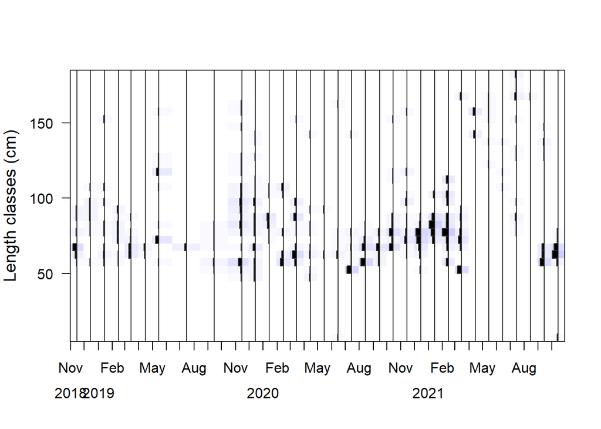

```r
par(mfrow = c(1,1))

yft_lfq_mod |>
  plot(
    Fname = "catch",           # Use restructured counts
    las = 1,
    ylab = 'Length classes (cm)',
    cex.main = 1.5,
    cex.lab = 1.2,
    cex.axis = 1
  )
```

## Summary for All Species

**What we’re doing:** Automate the entire LFQ workflow for all selected species using a loop.

**Why standardize to one year:** Allows easy visual comparison of seasonal patterns across species by plotting the annual cycle.

```
Press ENTER to see next species
```

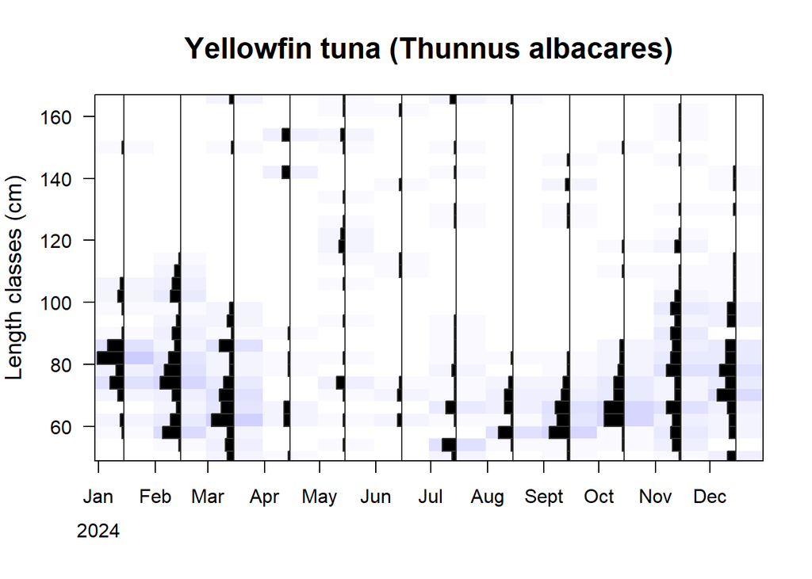

```
Press ENTER to see next species
```

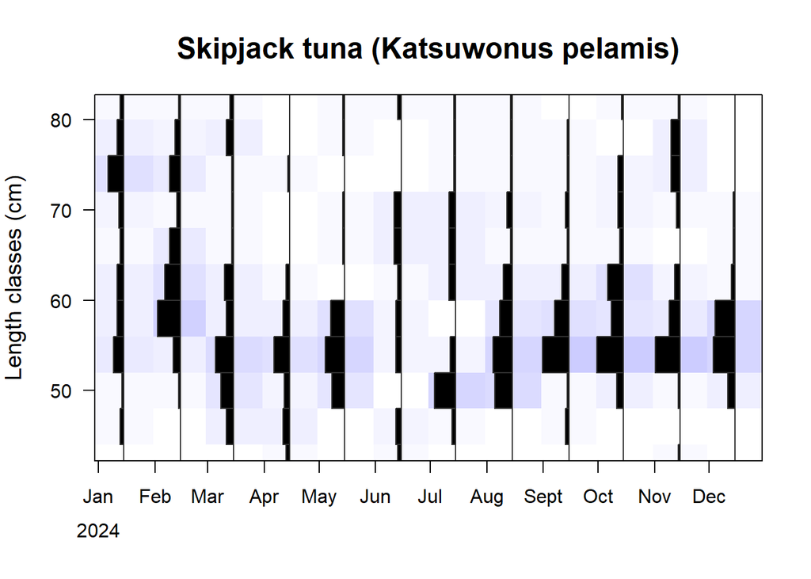

```
Press ENTER to see next species
```

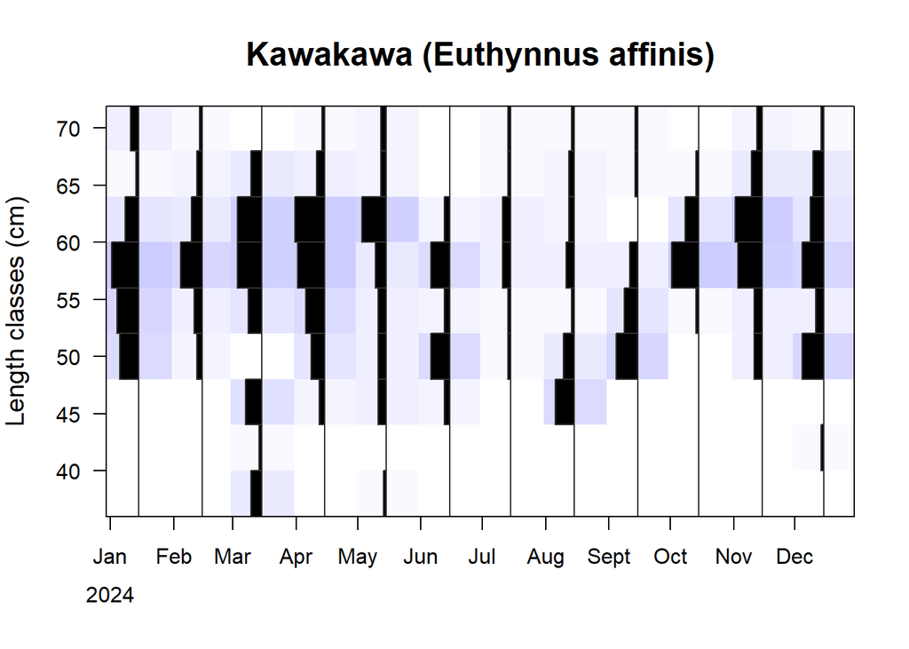

```
Press ENTER to see next species
```

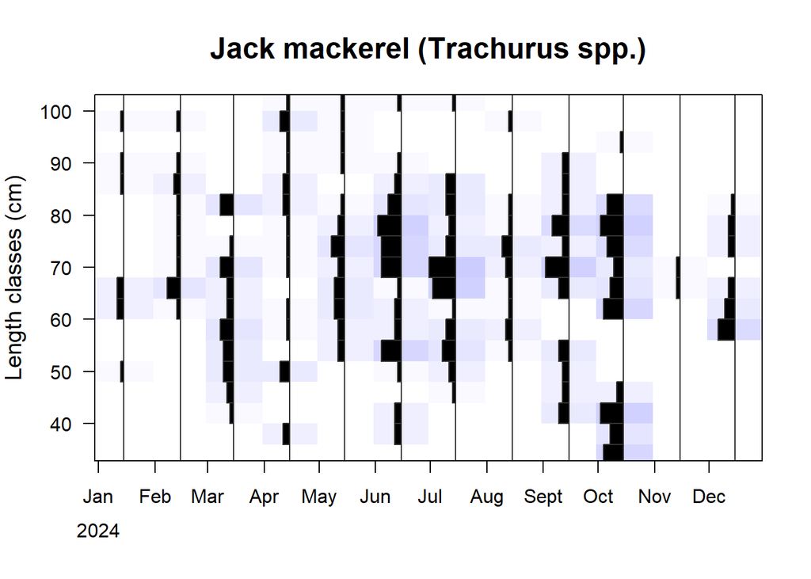

```
Press ENTER to see next species
```

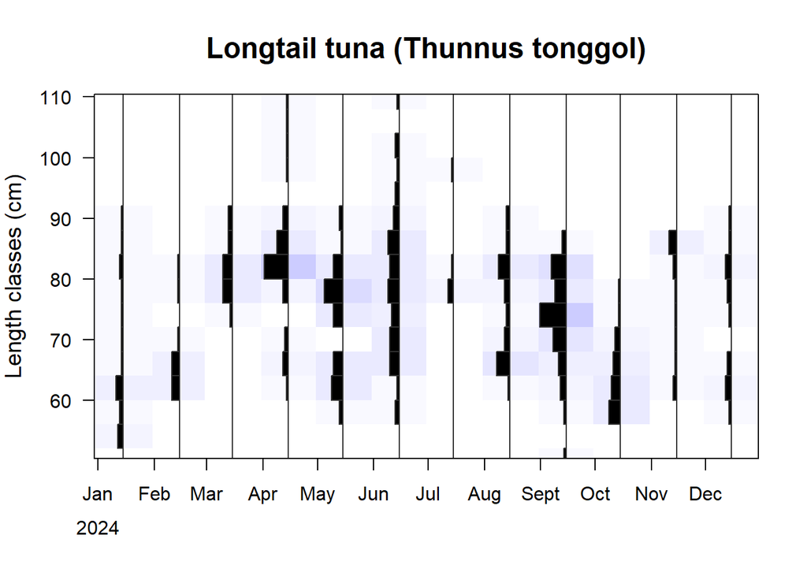

```
Press ENTER to see next species
```

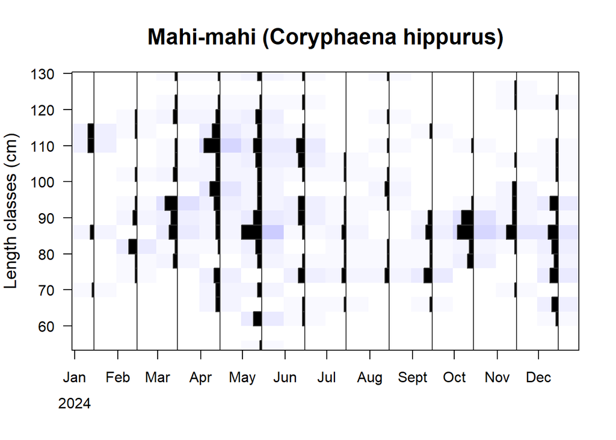

```
Press ENTER to see next species
```

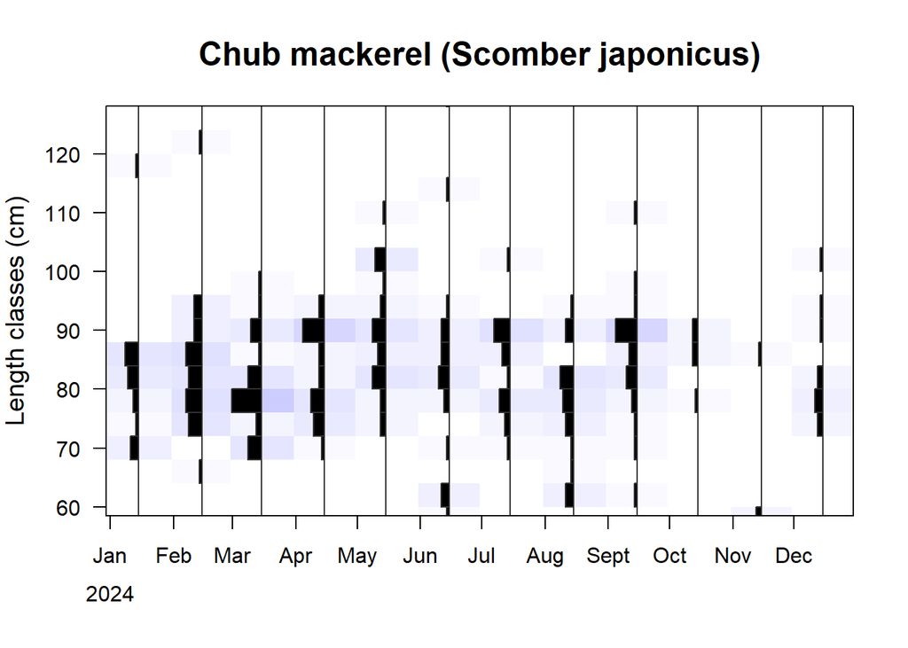

```
Press ENTER to see next species
```

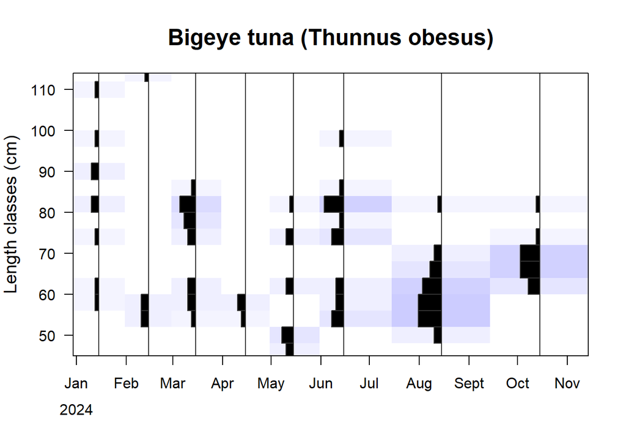

```r
for (j in 1:length(fishes)){

    readline(prompt = 'Press ENTER to see next species')

    aa = lw |>
        filter(fish_type_code == fishes[j]) |>
        mutate(
            # Standardize all dates to 2024 while keeping original month
            date = lubridate::make_date(year = 2024, month = month(date_dd_mm_yy), day = 15)
        )

    # Calculate length range for consistent axis limits
    bb = aa |> pull(length_cm) |> quantile(c(0.01, 0.99), na.rm = TRUE)

    aa |>
      TropFishR::lfqCreate(
        Lname = "length_cm",
        Dname = "date",
        bin_size = 2,
        species = fish_name$English_Name[j],
        length_unit = "cm",
        aggregate_dates = TRUE
        ) |>
      TropFishR::lfqModify(
        bin_size = 4,
        aggregate = "month",
        vectorise_catch = FALSE
        ) |>
      TropFishR::lfqRestructure(
        MA = 9,
        addl.sqrt = TRUE
        ) |>
        plot(
            Fname = "catch",
            las = 1,
            ylim = bb,
            main = paste0(fish_name$English_Name[j], " (", fish_name$Scientific_Name[j], ")"),
            ylab = 'Length classes (cm)',
            cex.main = 1.5,
            cex.lab = 1.2,
            cex.axis = 1
        )
}
```

## Bonus Information: Alternative LFQ Packages

Length-Frequency analysis is essential in data-limited fisheries. While `TropFishR` is comprehensive and implements the ELEFAN method, other R packages offer complementary approaches for length-based stock assessment.

### `fishdynr` Package

**Purpose:** Alternative implementation of FiSAT II methods for LFQ analysis with a slightly different workflow.

**Example: fishdynr workflow**

```r
library(fishdynr)

# Prepare data: fishdynr requires 'date' and 'length' columns
yft_for_fishdynr <- yft |>
  select(date = date_dd_mm_yy, length = length_cm) |>
  mutate(date = as.Date(date, format = "%d-%m-%Y"))

# Create LFQ object and plot
yft_lfq_fd <- lfq(dat = yft_for_fishdynr, bin_size = 4)
plot(yft_lfq_fd, hist.sc = 0.5)
```

### `LBSPR` Package

**Purpose:** Estimate Spawning Potential Ratio (SPR)—a key indicator of stock health—using length data and basic life history parameters.

**Advantages:** Simpler than ELEFAN; directly estimates current stock status relative to management reference points.

**Example: LBSPR workflow**

```r
library(LBSPR)

# 1. Set up life history parameters
MyPars <- new("LB_pars", L_units = "cm")
MyPars@Linf <- 170      # Asymptotic length (from literature)
MyPars@L50 <- 105       # Length at 50% maturity
MyPars@L95 <- 120       # Length at 95% maturity
MyPars@MK <- 1.5        # Natural Mortality / Growth rate ratio

# 2. Create length data object from your observations
MyLengths <- new("LBSPRlen", Len = yft$length_cm, LData = MyPars)

# 3. Fit the model
LBSPR_fit <- LBSPRfit(MyPars, MyLengths)

# 4. Plot results showing stock status
plot(LBSPR_fit)
```

**Key advantage:** LBSPR directly tells you if a stock is overfished (SPR too low) or healthy (SPR adequate), making it ideal for management advice.